# Demonstation of cheng package

chengvt

edited on 2016.05.16

# Package installation

The package is put on private repo on bitbucket. It can be installed using `install_bitbucket` funciton in devtools package.

```r
library(devtools)
install_bitbucket("chengvt/cheng", auth_user="keisoku",
            password="kikuchi", dependencies = TRUE)
library(cheng)
```

# EEM-related functions

## drawSpec: drawSpectra

Select and draw excitation or emission spectra. This function should also go to EEM package in the future.

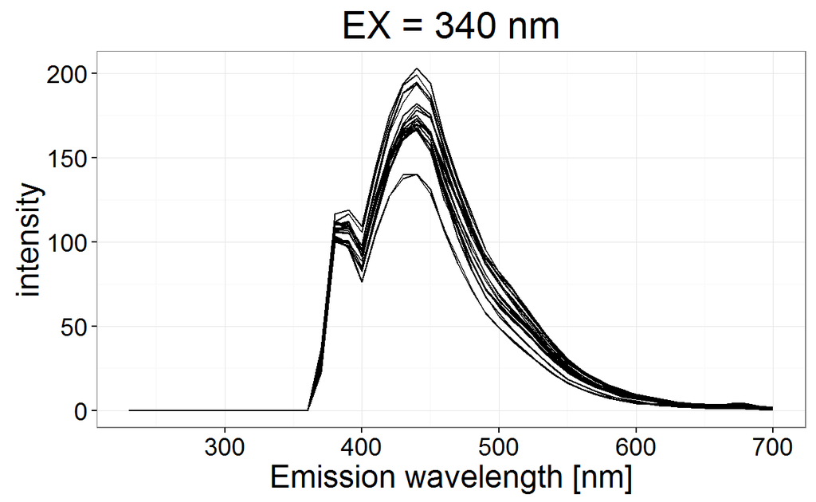

```r
require(EEM)
data(applejuice)
country <- sapply(strsplit(names(applejuice), split = "-"), "[", 1)

# ggplot
drawSpec(unfold(applejuice), EX = 340)
```

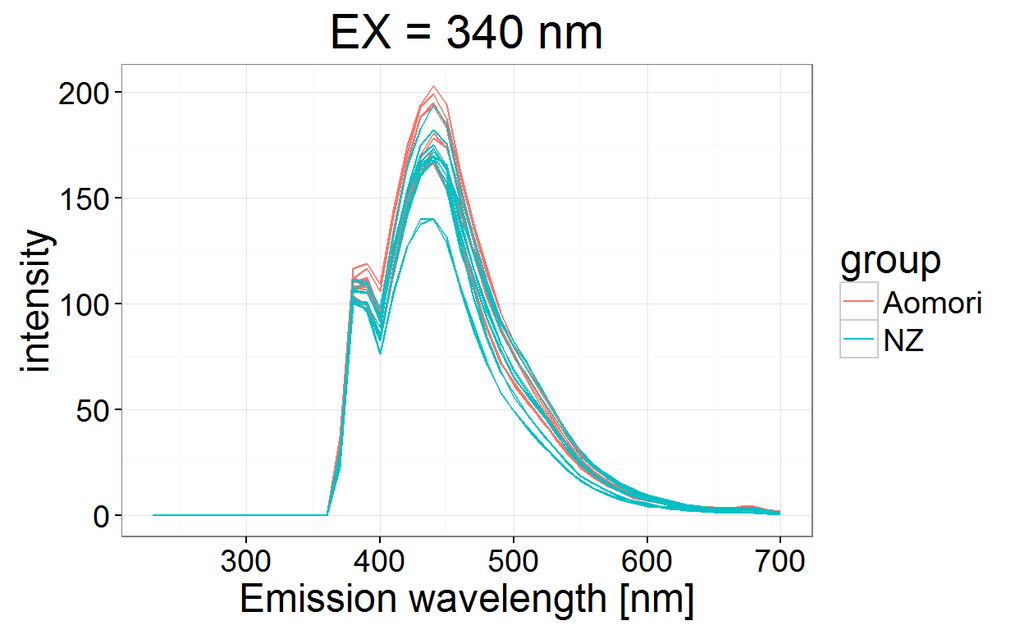

```r
drawSpec(unfold(applejuice), EX = 340, group = country)
```

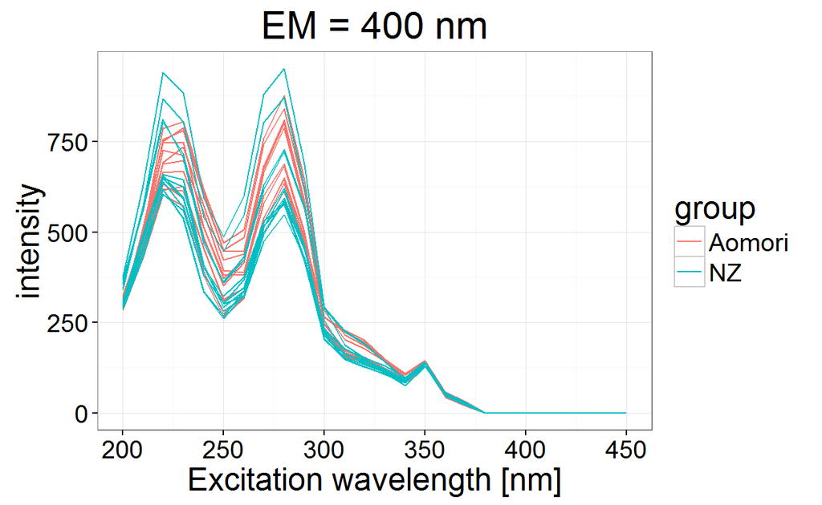

```r
drawSpec(unfold(applejuice), EM = 400, group = country)
```

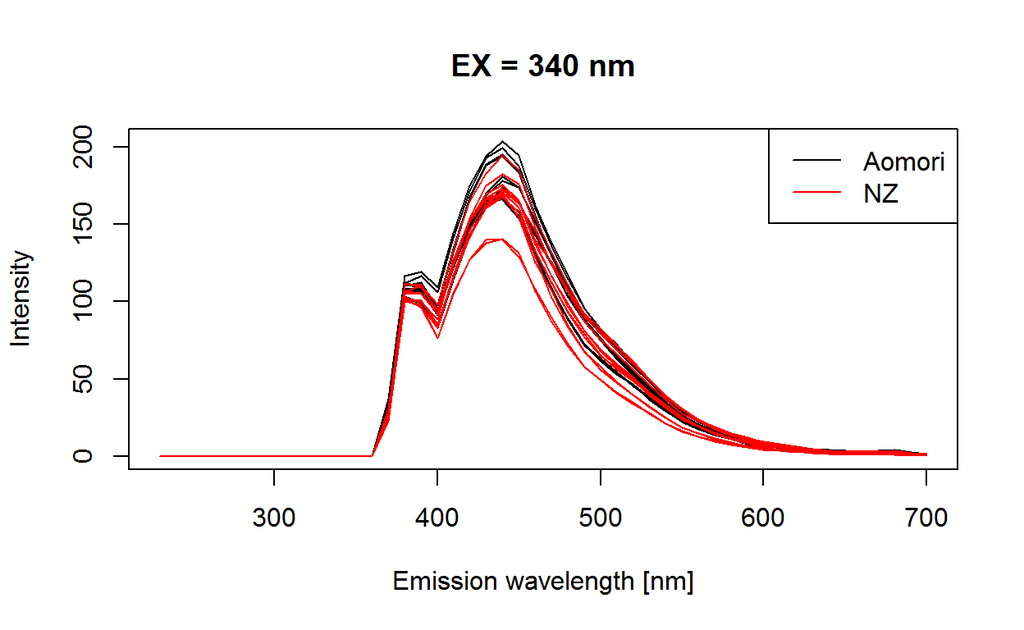

```r
# base plot
drawSpec(unfold(applejuice), EX = 340, group = country, ggplot = FALSE)
```

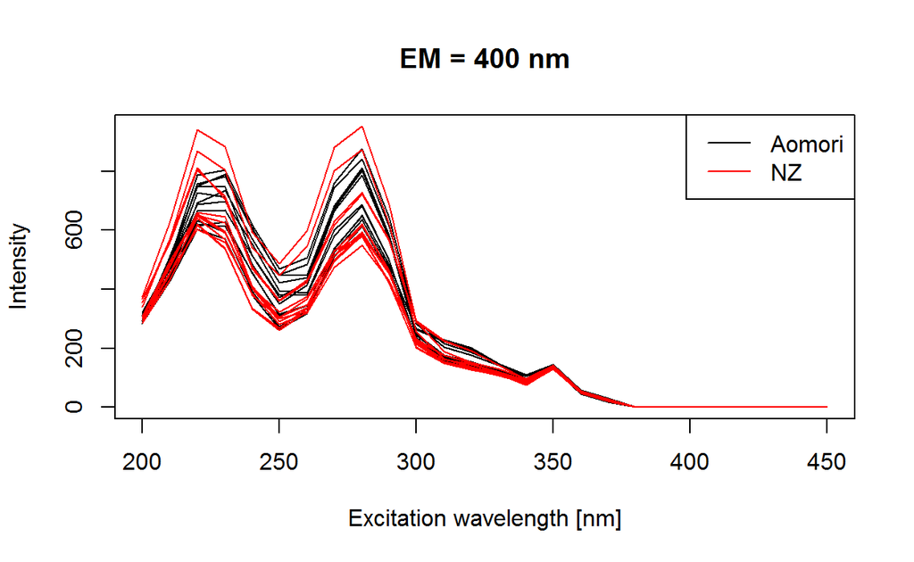

```r
drawSpec(unfold(applejuice), EM = 400, group = country, ggplot = FALSE)
```

## delZeroCol

Useful for deleting columns which are filled with zero for autoscaling operation.

```r
data(applejuice)
applejuice_uf <- unfold(applejuice)
dim(applejuice_uf)
```

```
## [1]   24 1248
```

```r
applejuice_uf_nozero <- delZeroCol(applejuice_uf)
dim(applejuice_uf_nozero)
```

```
## [1]  24 923
```

# PLS-related functions (using pls package)

## getR2: getR2 value from `mvr` class object

Alternative to pls package’s `R2`. While `R2` requires a `newdata` dataframe which combines both predictors and target, `getR2` lets you put in `newx` and `newy` separately. Aside from that, declaring `estimate` in `getR2` remind you which value you got.

```r
require(pls)
data(yarn)
model <- plsr(density ~ NIR, 6, data = yarn, validation = "CV")
R2(model)
```

```
## (Intercept)      1 comps      2 comps      3 comps      4 comps
##    -0.07545      0.96968      0.97781      0.99358      0.99883
##     5 comps      6 comps
##     0.99957      0.99969
```

```r
getR2(model, estimate = "train") # return R2 at particular ncomp without intercept value
```

```
## R2C = 0.9999 (ncomp = 6)
```

```
## [1] 0.9999099
```

```r
getR2(model, estimate = "CV")
```

```
## R2CV = 0.9997 (ncomp = 6)
```

```
## [1] 0.9996937
```

## getRMSE: getRMSE value from `mvr` class object

Alternative to pls package’s `RMSEP`. While `RMSEP` requires a `newdata` dataframe which combines both predictors and target, `getRMSE` lets you put in `newx` and `newy` separately. Aside from that, declaring `estimate` in `getRMSE` remind you which value you got.

```r
require(pls)
data(yarn)
model <- plsr(density ~ NIR, 6, data = yarn, validation = "CV")
RMSEP(model)
```

```
##        (Intercept)  1 comps  2 comps  3 comps  4 comps  5 comps  6 comps
## CV           27.46    5.151     4.04    2.021   0.5974   0.4708   0.4420
## adjCV        27.46    4.763     4.07    2.012   0.5867   0.4619   0.4351
```

```r
getRMSE(model, estimate = "train") # return RMSE at particular ncomp without intercept value
```

```
## RMSEC = 0.2514 (ncomp = 6)
```

```
## [1] 0.2513607
```

```r
getRMSE(model, estimate = "CV")
```

```
## RMSECV = 0.442 (ncomp = 6)
```

```
## [1] 0.441954
```

## getVIP: getVIP from `mvr` class object

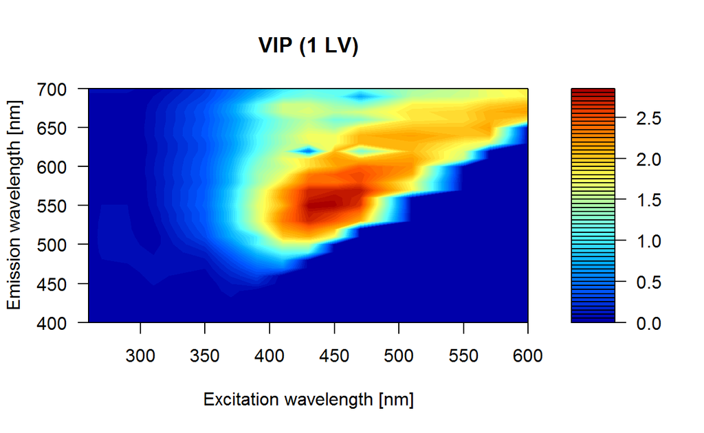

```r
# load data
require(EEM)
data(gluten)
gluten_uf <- unfold(gluten) # unfold list into matrix
# delete columns with NA values
index <- colSums(is.na(gluten_uf)) == 0
gluten_uf <- gluten_uf[, index]
gluten_ratio <- as.numeric(names(gluten))

# build pls model using pls model
require(pls)
model <- plsr(gluten_ratio ~ gluten_uf, ncomp = 10, method = "oscorespls")
drawEEM(getVIP(model), 1) # color contour
```

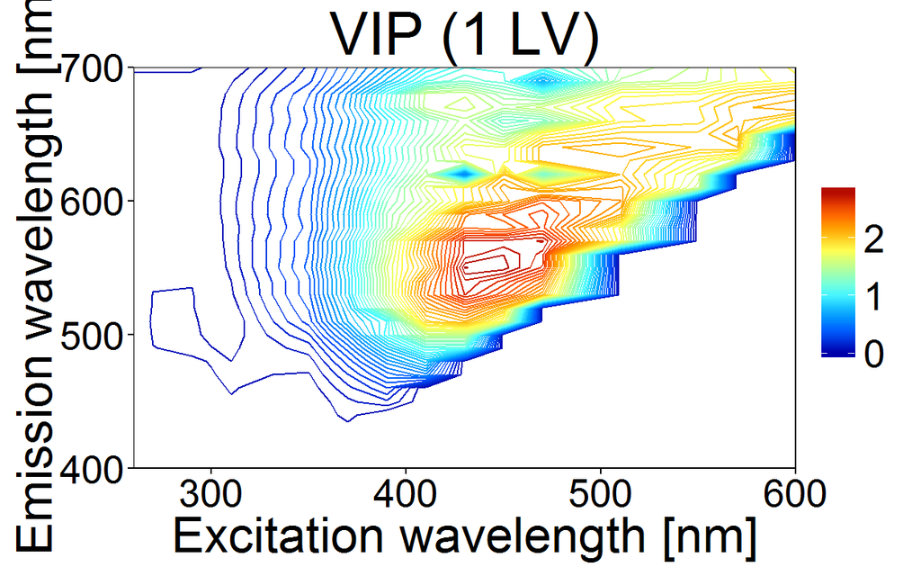

```r
drawEEMgg(getVIP(model), 1, nlevel = 50) # normal contour
```

## plot_ncomp: Plotting selected ncomp

Plotting ncomp of pls model.

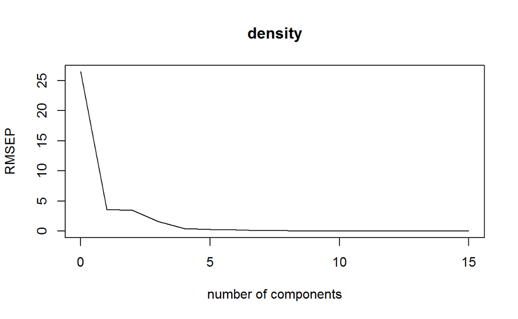

```r
require(pls)
data(yarn)
model <- plsr(density ~ NIR, 15, data = yarn)

# plot ncomp
validationplot(model) # available function in pls package
```

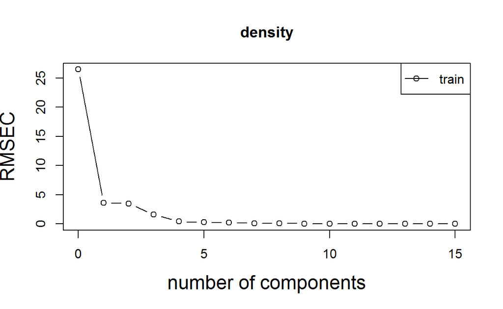

```r
plot_ncomp(model) # offer a new format for easier view
```

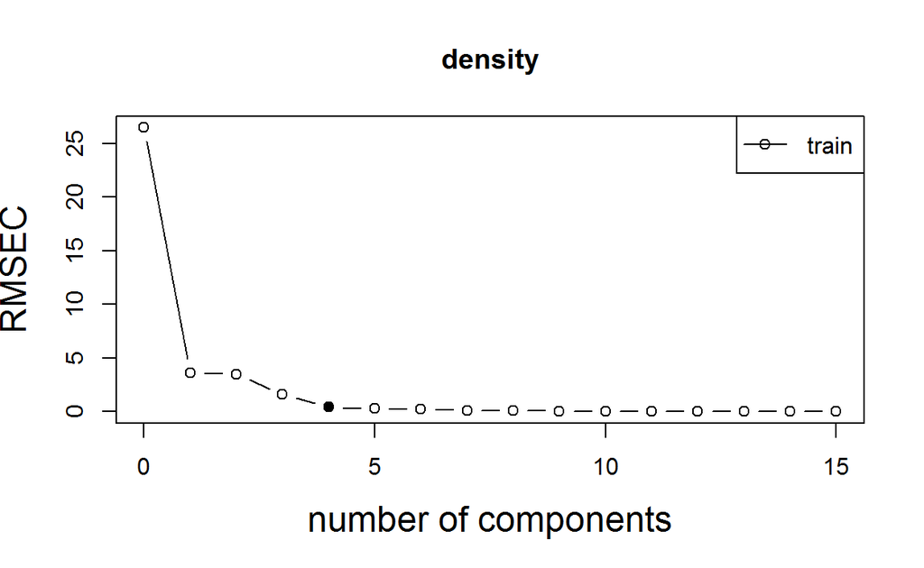

```r
plot.new()
plot_ncomp(model, ncomp = 4) # fill in the point of the selected LV
```

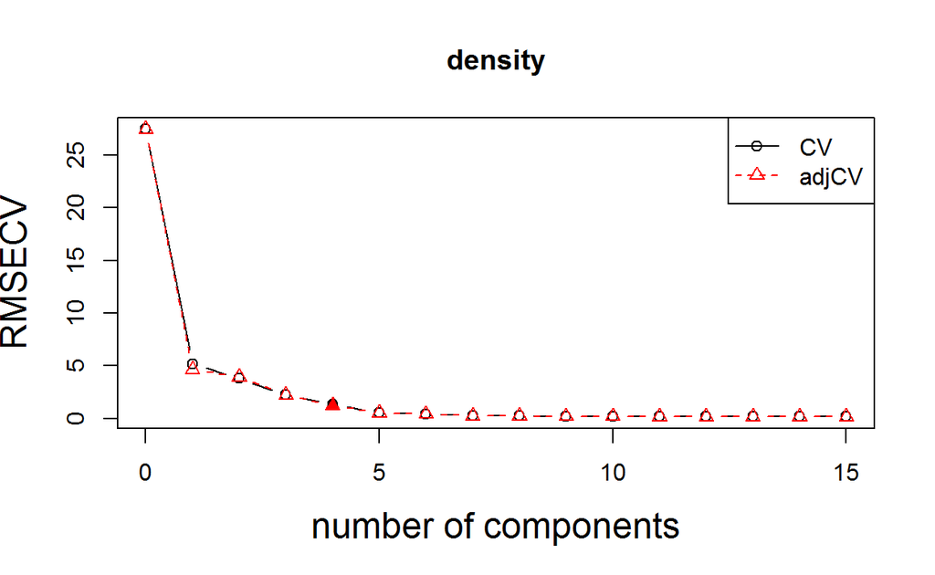

```r
# now build pls model again using cross-validation
model <- plsr(density ~ NIR, 15, data = yarn, validation = "CV")
plot_ncomp(model) # notice that y-axis label change to RMSECV
plot_ncomp(model, ncomp = 4) # fill in the point of the selected LV
```

## plotVIP

A lazy function which binds `drawEEM` and `getVIP` together.

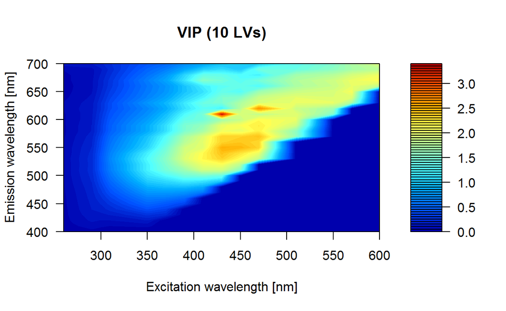

```r
# load data
require(EEM)
data(gluten)
gluten_uf <- unfold(gluten) # unfold list into matrix
# delete columns with NA values
index <- colSums(is.na(gluten_uf)) == 0
gluten_uf <- gluten_uf[, index]
gluten_ratio <- as.numeric(names(gluten))

# build pls model using pls model
require(pls)
model <- plsr(gluten_ratio ~ gluten_uf, ncomp = 10, method = "oscorespls")
plotVIP(model) # color contour
```

## plsplot: Plotting pls prediction result

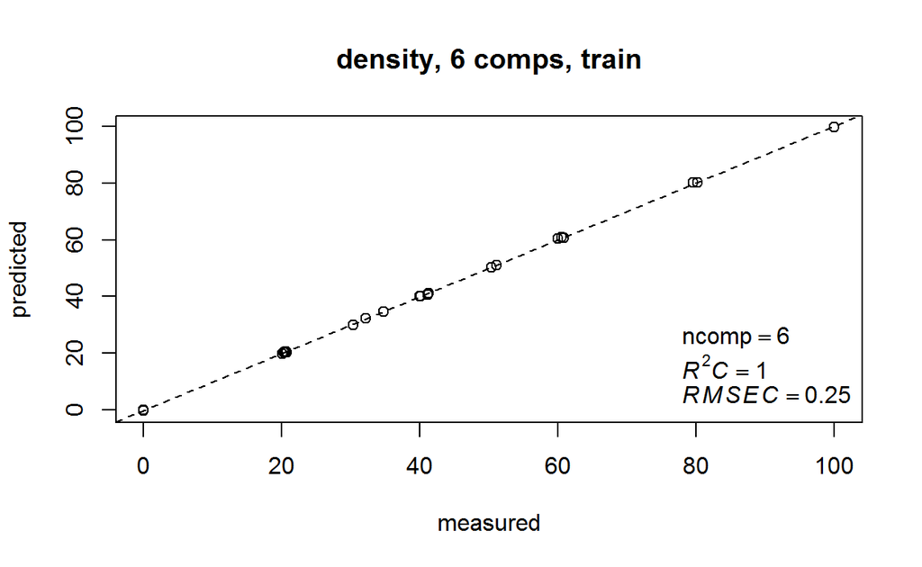

```r
require(pls)
data(yarn)
model <- plsr(density ~ NIR, 6, data = yarn, validation = "CV")
plsplot(model) # calibration set result
```

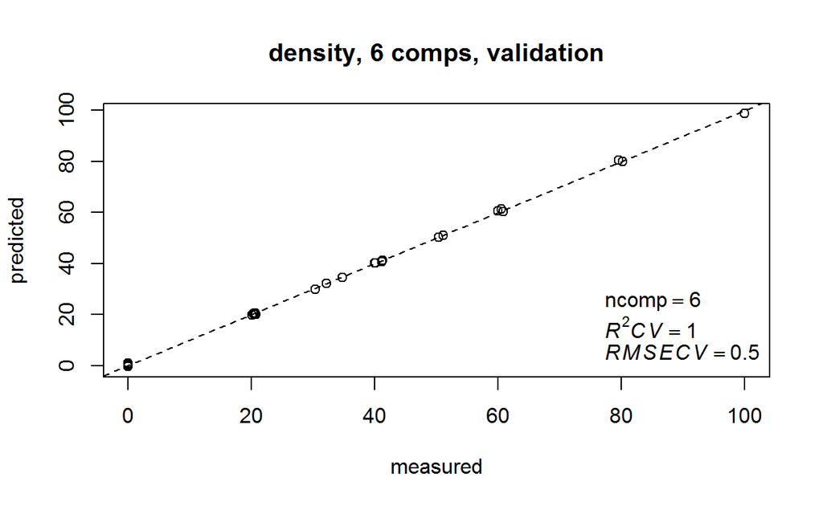

```r
plsplot(model, estimate = "CV") # cross validation set result
```

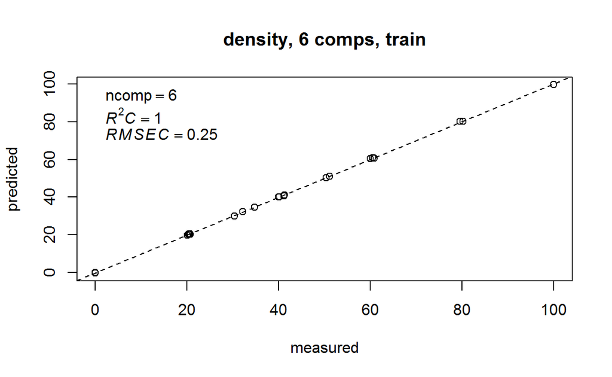

```r
## customizing the graphs
plsplot(model, location = "topleft") # change legend position
```

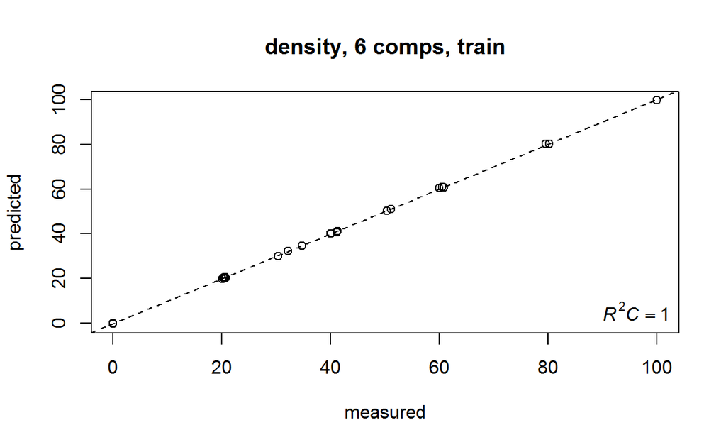

```r
plsplot(model, show = "R2") # show only R2
```

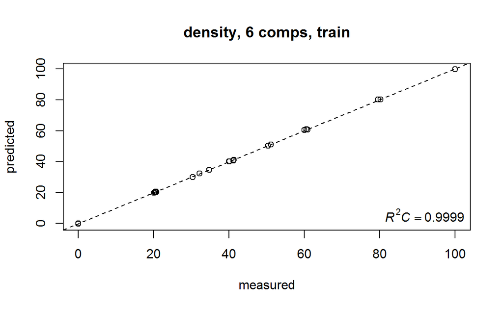

```r
plsplot(model, show = "R2", round = 4) # round to four digits
```

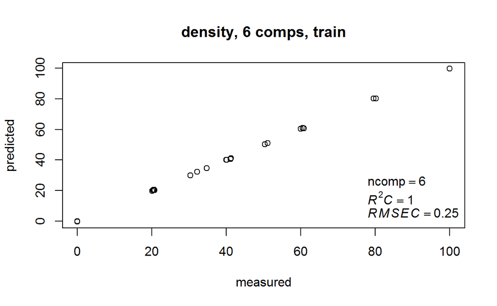

```r
plsplot(model, fitline = FALSE) # get rid of fitline
```

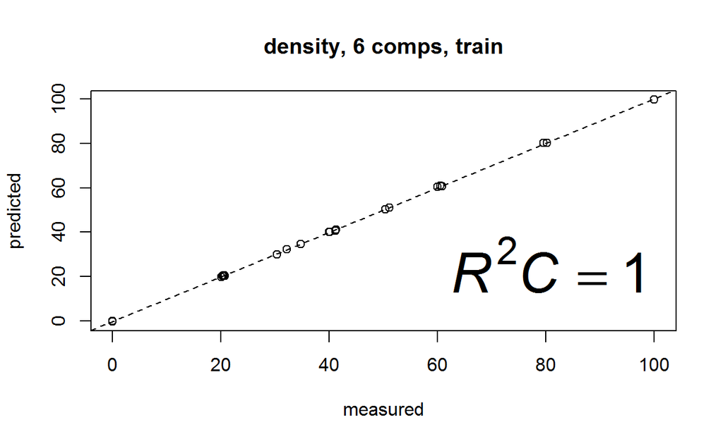

```r
plsplot(model, show = "R2", cex.stats = 3) # bigger stats font
```

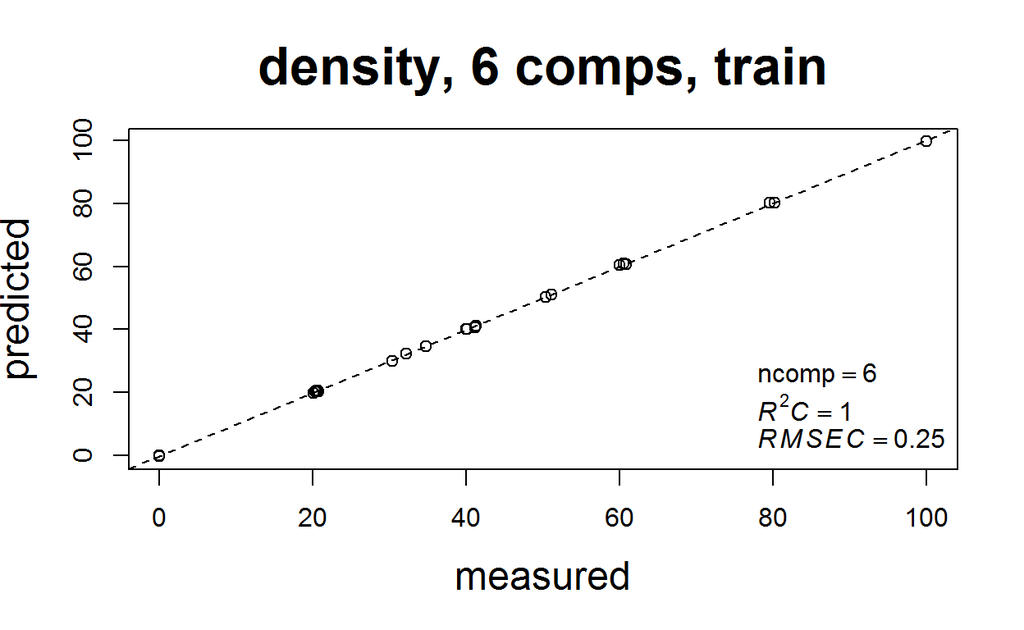

```r
plsplot(model, cex.lab = 1.5, cex.main = 2) # bigger labels font
```

## plsplot2: Plotting pls prediction result

`plsplot2` plots both calibration and validation on the same graph

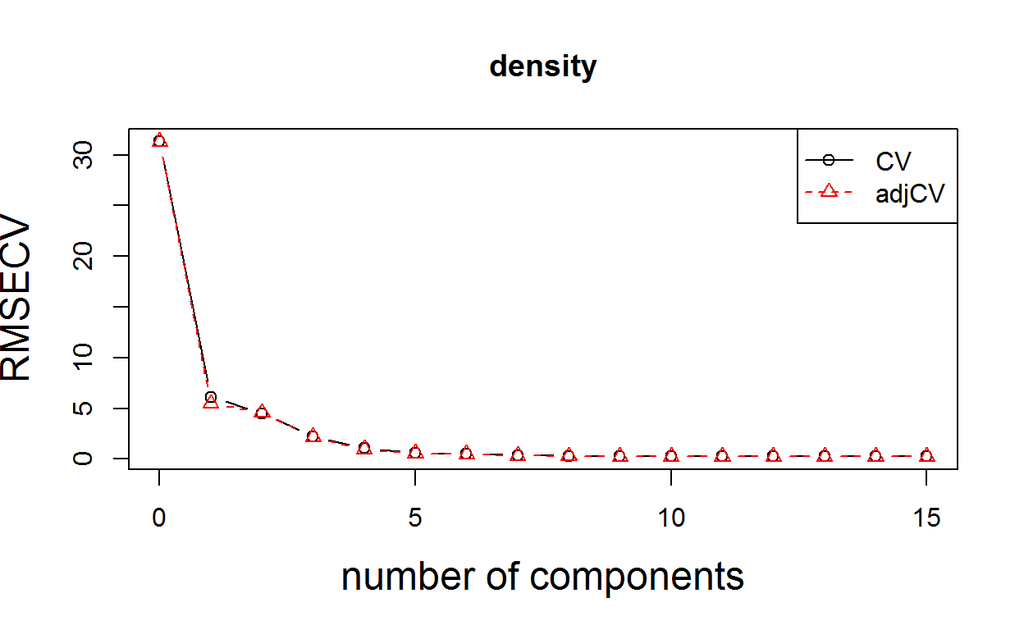

```r
require(pls)
data(yarn)
yarn.cal <- yarn[yarn$train,]
yarn.val <- yarn[!yarn$train,]
model <- plsr(density ~ NIR, 15, data = yarn.cal, validation = "CV")
plot_ncomp(model)
```

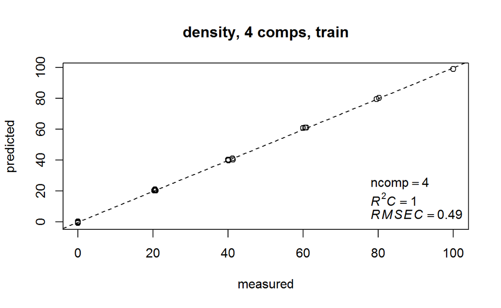

```r
ncomp <- 4 # 4 components seem to be appropriate
model <- plsr(density ~ NIR, ncomp, data = yarn.cal) # recalculate

plsplot(model) # calibration
```

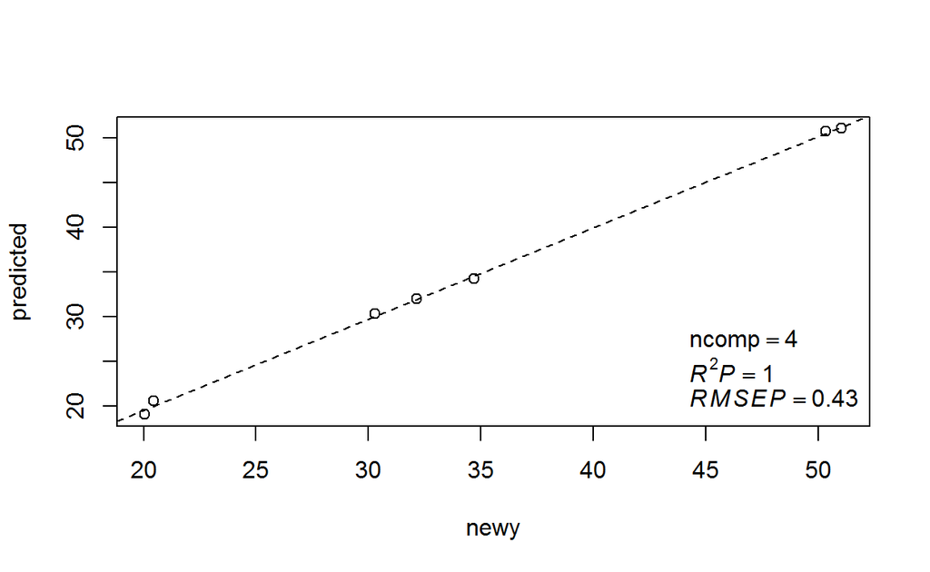

```r
plsplot(model, newx = yarn.val$NIR, newy = yarn.val$density) # validation
```

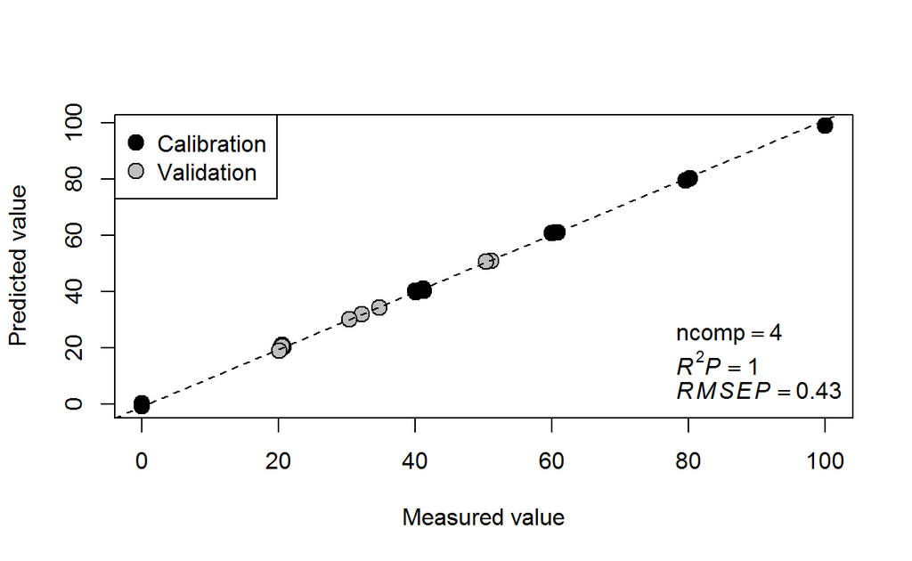

```r
# now put those two plots together
plsplot2(model, newx = yarn.val$NIR, newy = yarn.val$density) # calibration and validation
```

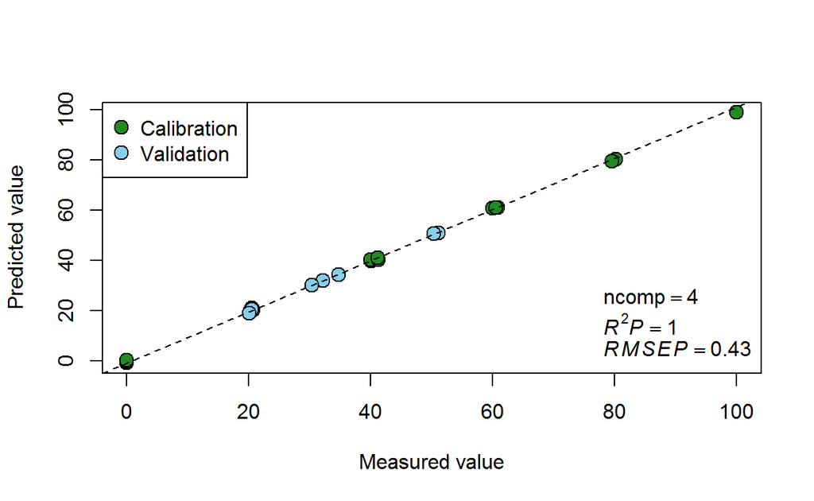

```r
plsplot2(model, newx = yarn.val$NIR, newy = yarn.val$density, col.cal = "forestgreen", col.val = "skyblue") # change point colors
```

## trainPLS

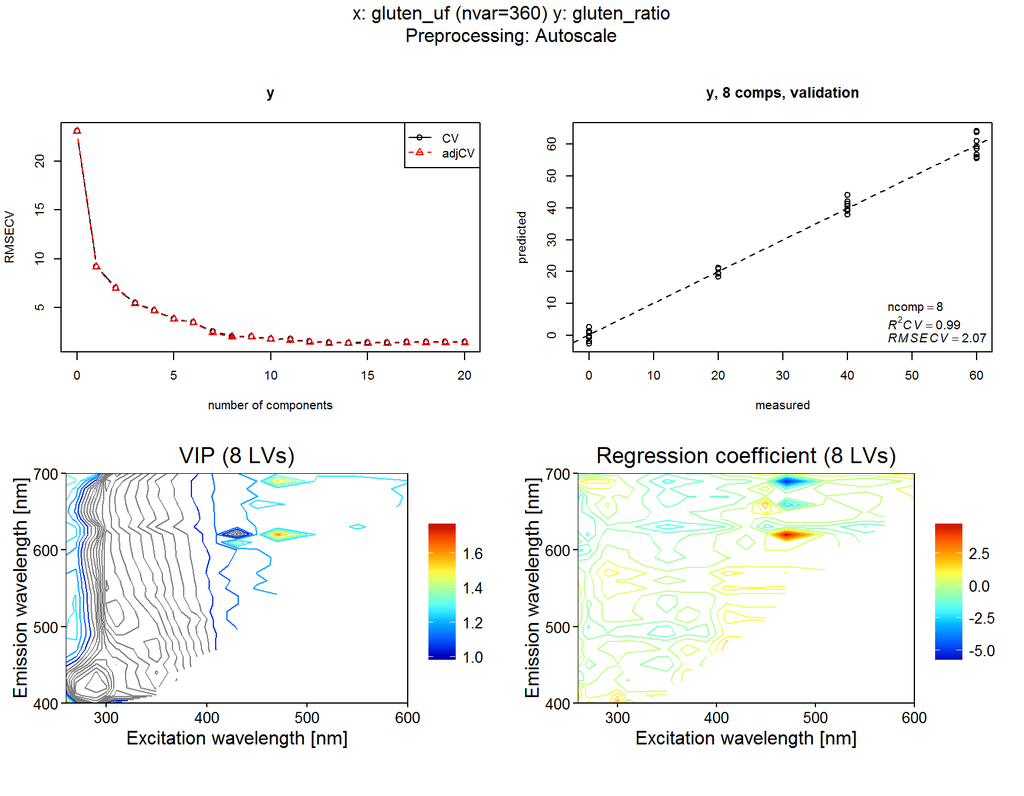

```
##           preprocessing nvar ncomp  R2C RMSEC R2CV RMSECV
## 1        Mean-centering  496     7 1.00  1.42 0.99   2.25
## 2 Norm + Mean-centering  496     5 0.98  2.98 0.97   3.96
## 3             Autoscale  360     8 1.00  1.15 0.99   2.07
```

```r
# load data
require(EEM)
data(gluten)
gluten_uf <- unfold(gluten) # unfold list into matrix
# delete columns with NA values
index <- colSums(is.na(gluten_uf)) == 0
gluten_uf <- gluten_uf[, index]
gluten_ratio <- as.numeric(names(gluten))

# build pls model using pls model
require(cheng)
trainPLS(x = gluten_uf, y = gluten_ratio)
```

if the number of componenents is too high, you can try increasing the threshold, which is default at 0.02

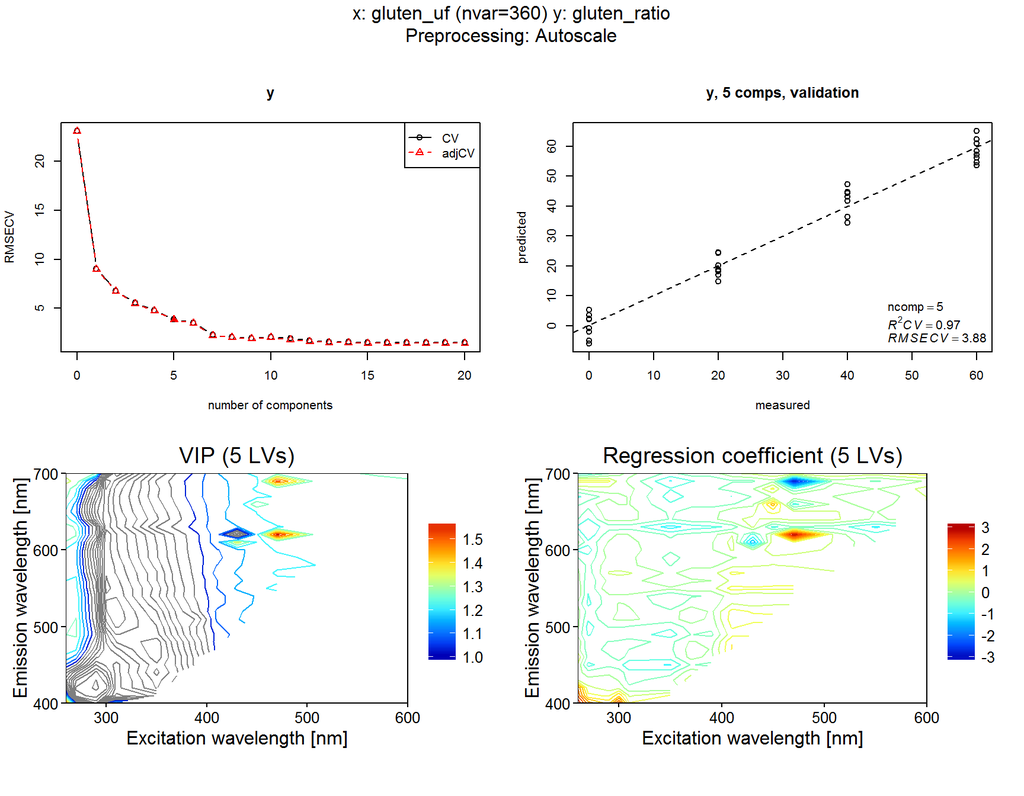

```
##           preprocessing nvar ncomp  R2C RMSEC R2CV RMSECV
## 1        Mean-centering  496     3 0.97  3.74 0.95   4.82
## 2 Norm + Mean-centering  496     5 0.98  2.98 0.97   3.99
## 3             Autoscale  360     5 0.98  2.86 0.97   3.88
```

```r
trainPLS(x = gluten_uf, y = gluten_ratio, threshold = 0.1)
```

## trainPLS2

Train PLS for train dataset by cross-validation. This is different from trainPLS as you have to specify the preprocessing method manually. In addition, the variable reduction by VIP can be done automatically with number of cycles specifiable.

```r
result <- trainPLS2(x = gluten_uf, y = gluten_ratio, cycles = 2)
```

[output not shown]

The number of variables will decrease with each cycle.

# Raman-related functions

## addLabel

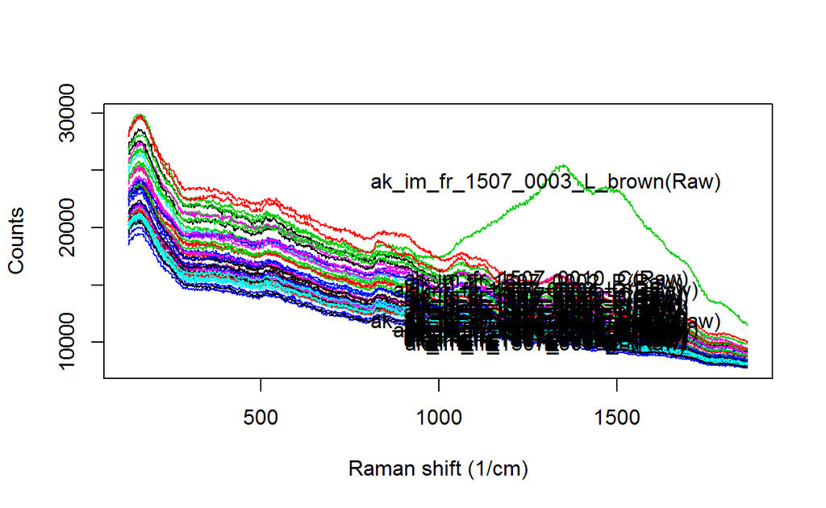

```r
data(raman)
plotRaman(raman)
# labeling lines at x=1300
addLabel(raman, 1300)
```